# Loans Dataset Exploration

## Preliminary Wrangling

#### What is the structure of your dataset?

> This data set contains 113,937 loans with 81 variables on each loan, including loan amount, borrower rate (or interest rate), current loan status, borrower income, and many others.

```python
# import all packages and set plots to be embedded inline
import numpy as np
import pandas as pd
import matplotlib.pyplot as plt
import seaborn as sb
import json
import time
from timeit import default_timer as timer
%matplotlib inline
```

## Step 1.1: Investigation of the data

```python
# load in the dataset into a pandas dataframe, print statistics
df = pd.read_csv('prosperLoanData.csv')
```

```python
# high-level overview of data shape and composition
print(df.shape)
print(df.dtypes)
df.head(10)
```

```
(113937, 81)
ListingKey                      object
ListingNumber                    int64
ListingCreationDate             object
CreditGrade                     object
Term                             int64
                                ...
PercentFunded                  float64
Recommendations                  int64
InvestmentFromFriendsCount       int64
InvestmentFromFriendsAmount    float64
Investors                        int64
Length: 81, dtype: object
```

|  | ListingKey | ListingNumber | ListingCreationDate | CreditGrade | Term | LoanStatus | ClosedDate | BorrowerAPR | BorrowerRate | LenderYield | ... | LP_ServiceFees | LP_CollectionFees | LP_GrossPrincipalLoss | LP_NetPrincipalLoss | LP_NonPrincipalRecoverypayments | PercentFunded | Recommendations | InvestmentFromFriendsCount | InvestmentFromFriendsAmount | Investors |
| --- | --- | --- | --- | --- | --- | --- | --- | --- | --- | --- | --- | --- | --- | --- | --- | --- | --- | --- | --- | --- | --- |
| 0 | 1021339766868145413AB3B | 193129 | 2007-08-26 19:09:29.263000000 | C | 36 | Completed | 2009-08-14 00:00:00 | 0.16516 | 0.1580 | 0.1380 | ... | -133.18 | 0.0 | 0.0 | 0.0 | 0.0 | 1.0 | 0 | 0 | 0.0 | 258 |
| 1 | 10273602499503308B223C1 | 1209647 | 2014-02-27 08:28:07.900000000 | NaN | 36 | Current | NaN | 0.12016 | 0.0920 | 0.0820 | ... | 0.00 | 0.0 | 0.0 | 0.0 | 0.0 | 1.0 | 0 | 0 | 0.0 | 1 |
| 2 | 0EE9337825851032864889A | 81716 | 2007-01-05 15:00:47.090000000 | HR | 36 | Completed | 2009-12-17 00:00:00 | 0.28269 | 0.2750 | 0.2400 | ... | -24.20 | 0.0 | 0.0 | 0.0 | 0.0 | 1.0 | 0 | 0 | 0.0 | 41 |
| 3 | 0EF5356002482715299901A | 658116 | 2012-10-22 11:02:35.010000000 | NaN | 36 | Current | NaN | 0.12528 | 0.0974 | 0.0874 | ... | -108.01 | 0.0 | 0.0 | 0.0 | 0.0 | 1.0 | 0 | 0 | 0.0 | 158 |
| 4 | 0F023589499656230C5E3E2 | 909464 | 2013-09-14 18:38:39.097000000 | NaN | 36 | Current | NaN | 0.24614 | 0.2085 | 0.1985 | ... | -60.27 | 0.0 | 0.0 | 0.0 | 0.0 | 1.0 | 0 | 0 | 0.0 | 20 |
| 5 | 0F05359734824199381F61D | 1074836 | 2013-12-14 08:26:37.093000000 | NaN | 60 | Current | NaN | 0.15425 | 0.1314 | 0.1214 | ... | -25.33 | 0.0 | 0.0 | 0.0 | 0.0 | 1.0 | 0 | 0 | 0.0 | 1 |
| 6 | 0F0A3576754255009D63151 | 750899 | 2013-04-12 09:52:56.147000000 | NaN | 36 | Current | NaN | 0.31032 | 0.2712 | 0.2612 | ... | -22.95 | 0.0 | 0.0 | 0.0 | 0.0 | 1.0 | 0 | 0 | 0.0 | 1 |
| 7 | 0F1035772717087366F9EA7 | 768193 | 2013-05-05 06:49:27.493000000 | NaN | 36 | Current | NaN | 0.23939 | 0.2019 | 0.1919 | ... | -69.21 | 0.0 | 0.0 | 0.0 | 0.0 | 1.0 | 0 | 0 | 0.0 | 1 |
| 8 | 0F043596202561788EA13D5 | 1023355 | 2013-12-02 10:43:39.117000000 | NaN | 36 | Current | NaN | 0.07620 | 0.0629 | 0.0529 | ... | -16.77 | 0.0 | 0.0 | 0.0 | 0.0 | 1.0 | 0 | 0 | 0.0 | 1 |
| 9 | 0F043596202561788EA13D5 | 1023355 | 2013-12-02 10:43:39.117000000 | NaN | 36 | Current | NaN | 0.07620 | 0.0629 | 0.0529 | ... | -16.77 | 0.0 | 0.0 | 0.0 | 0.0 | 1.0 | 0 | 0 | 0.0 | 1 |

10 rows × 81 columns

```python
df.dtypes
```

```
ListingKey                      object
ListingNumber                    int64
ListingCreationDate             object
CreditGrade                     object
Term                             int64
                                ...
PercentFunded                  float64
Recommendations                  int64
InvestmentFromFriendsCount       int64
InvestmentFromFriendsAmount    float64
Investors                        int64
Length: 81, dtype: object
```

```python
df.info()
```

```
<class 'pandas.core.frame.DataFrame'>
RangeIndex: 113937 entries, 0 to 113936
Data columns (total 81 columns):
 #   Column                               Non-Null Count   Dtype
---  ------                               --------------   -----
 0   ListingKey                           113937 non-null  object
 1   ListingNumber                        113937 non-null  int64
 2   ListingCreationDate                  113937 non-null  object
 3   CreditGrade                          28953 non-null   object
 4   Term                                 113937 non-null  int64
 5   LoanStatus                           113937 non-null  object
 6   ClosedDate                           55089 non-null   object
 7   BorrowerAPR                          113912 non-null  float64
 8   BorrowerRate                         113937 non-null  float64
 9   LenderYield                          113937 non-null  float64
```

[output cut: 73 more lines]

```python
df.nunique()
```

```
ListingKey                     113066
ListingNumber                  113066
ListingCreationDate            113064
CreditGrade                         8
Term                                3
                                ...
PercentFunded                     719
Recommendations                    17
InvestmentFromFriendsCount         14
InvestmentFromFriendsAmount       726
Investors                         751
Length: 81, dtype: int64
```

```python
df.isnull().sum()
```

```
ListingKey                         0
ListingNumber                      0
ListingCreationDate                0
CreditGrade                    84984
Term                               0
                               ...
PercentFunded                      0
Recommendations                    0
InvestmentFromFriendsCount         0
InvestmentFromFriendsAmount        0
Investors                          0
Length: 81, dtype: int64
```

```python
df.duplicated().sum()
```

```
0
```

### What is/are the main feature(s) of interest in your dataset?

##### After investigating the dataset variables and from my finance background I choiced the most relevent variable to be used and specified it as follow :-

> > `'ListingCreationDate','LoanKey','LoanOriginalAmount', 'CreditGrade', 'Term', 'LoanStatus','BorrowerAPR', 'BorrowerRate','LenderYield','EstimatedEffectiveYield','EstimatedLoss', 'EstimatedReturn','ProsperRating (numeric)','ProsperScore', 'BorrowerState', 'Occupation','EmploymentStatus','IsBorrowerHomeowner', 'AmountDelinquent','LP_CustomerPayments','AvailableBankcardCredit','IncomeRange','DebtToIncomeRatio','IncomeVerifiable' ,'LP_GrossPrincipalLoss','LP_NetPrincipalLoss','Investors','LP_ServiceFees'`

### `Creating a new dataframe with custom columns to conduct a better focused exploratery analysis`

```python
df2 = df[['LoanKey','ListingCreationDate','LoanOriginalAmount', 'CreditGrade', 'Occupation','Term', 'LoanStatus', 'BorrowerRate','LenderYield','EstimatedEffectiveYield','EstimatedLoss', 'EstimatedReturn','ProsperRating (numeric)','ProsperScore',
          'BorrowerState','EmploymentStatus','IsBorrowerHomeowner', 'AmountDelinquent','LP_CustomerPayments','AvailableBankcardCredit','IncomeRange','DebtToIncomeRatio',
          'IncomeVerifiable' ,'LP_GrossPrincipalLoss','LP_NetPrincipalLoss','Investors','LP_ServiceFees']].copy()
```

```python
#Convert `ListingCreationDate` columns to date-type.
df2['ListingCreationDate']= pd.to_datetime(df2['ListingCreationDate'])
# extract the Year from loan date
df2['LoanYear'] = df2.ListingCreationDate.dt.year
df2 = df2.drop(columns=['ListingCreationDate'])
```

```python
df2.head()
```

|  | LoanKey | LoanOriginalAmount | CreditGrade | Occupation | Term | LoanStatus | BorrowerRate | LenderYield | EstimatedEffectiveYield | EstimatedLoss | ... | LP_CustomerPayments | AvailableBankcardCredit | IncomeRange | DebtToIncomeRatio | IncomeVerifiable | LP_GrossPrincipalLoss | LP_NetPrincipalLoss | Investors | LP_ServiceFees | LoanYear |
| --- | --- | --- | --- | --- | --- | --- | --- | --- | --- | --- | --- | --- | --- | --- | --- | --- | --- | --- | --- | --- | --- |
| 0 | E33A3400205839220442E84 | 9425 | C | Other | 36 | Completed | 0.1580 | 0.1380 | NaN | NaN | ... | 11396.14 | 1500.0 | $25,000-49,999 | 0.17 | True | 0.0 | 0.0 | 258 | -133.18 | 2007 |
| 1 | 9E3B37071505919926B1D82 | 10000 | NaN | Professional | 36 | Current | 0.0920 | 0.0820 | 0.07960 | 0.0249 | ... | 0.00 | 10266.0 | $50,000-74,999 | 0.18 | True | 0.0 | 0.0 | 1 | 0.00 | 2014 |
| 2 | 6954337960046817851BCB2 | 3001 | HR | Other | 36 | Completed | 0.2750 | 0.2400 | NaN | NaN | ... | 4186.63 | NaN | Not displayed | 0.06 | True | 0.0 | 0.0 | 41 | -24.20 | 2007 |
| 3 | A0393664465886295619C51 | 10000 | NaN | Skilled Labor | 36 | Current | 0.0974 | 0.0874 | 0.08490 | 0.0249 | ... | 5143.20 | 30754.0 | $25,000-49,999 | 0.15 | True | 0.0 | 0.0 | 158 | -108.01 | 2012 |
| 4 | A180369302188889200689E | 15000 | NaN | Executive | 36 | Current | 0.2085 | 0.1985 | 0.18316 | 0.0925 | ... | 2819.85 | 695.0 | $100,000+ | 0.26 | True | 0.0 | 0.0 | 20 | -60.27 | 2013 |

5 rows × 27 columns

```python
df2.info()
```

```
<class 'pandas.core.frame.DataFrame'>
RangeIndex: 113937 entries, 0 to 113936
Data columns (total 27 columns):
 #   Column                   Non-Null Count   Dtype
---  ------                   --------------   -----
 0   LoanKey                  113937 non-null  object
 1   LoanOriginalAmount       113937 non-null  int64
 2   CreditGrade              28953 non-null   object
 3   Occupation               110349 non-null  object
 4   Term                     113937 non-null  int64
 5   LoanStatus               113937 non-null  object
 6   BorrowerRate             113937 non-null  float64
 7   LenderYield              113937 non-null  float64
 8   EstimatedEffectiveYield  84853 non-null   float64
 9   EstimatedLoss            84853 non-null   float64
```

[output cut: 19 more lines]

```python
numeric_vars = ['LoanOriginalAmount', 'Term','EstimatedReturn','LP_NetPrincipalLoss','AvailableBankcardCredit','BorrowerRate','LenderYield', 'AmountDelinquent', 'DebtToIncomeRatio', 'Investors', 'BorrowerAPR', 'LP_ServiceFees']
categoric_vars = ['CreditGrade', 'Occupation', 'LoanStatus','BorrowerState','EmploymentStatus', 'IsBorrowerHomeowner','IncomeRange']
```

```python
df2.to_csv('prosperLoanData2.csv')
```

```python
df2.nunique()
```

```
LoanKey                    113066
LoanOriginalAmount           2468
CreditGrade                     8
Occupation                     67
Term                            3
LoanStatus                     12
BorrowerRate                 2294
LenderYield                  2283
EstimatedEffectiveYield      1582
EstimatedLoss                 120
EstimatedReturn              1476
ProsperRating (numeric)         7
ProsperScore                   11
BorrowerState                  51
EmploymentStatus                8
IsBorrowerHomeowner             2
AmountDelinquent             7059
LP_CustomerPayments         78523
AvailableBankcardCredit     31829
IncomeRange                     8
DebtToIncomeRatio            1207
IncomeVerifiable                2
LP_GrossPrincipalLoss       15848
LP_NetPrincipalLoss         15709
Investors                     751
LP_ServiceFees              19813
LoanYear                       10
dtype: int64
```

### What features in the dataset do you think will help support your investigation into your feature(s) of interest?

> `I will have more clear idea while expermenting some visuals and statistics on those variable to drive our main focus`

```python
#summary statictics for our dataset
print(df2.describe())
```

```
       LoanOriginalAmount           Term   BorrowerRate    LenderYield  \
count        113937.00000  113937.000000  113937.000000  113937.000000
mean           8337.01385      40.830248       0.192764       0.182701
std            6245.80058      10.436212       0.074818       0.074516
min            1000.00000      12.000000       0.000000      -0.010000
25%            4000.00000      36.000000       0.134000       0.124200
50%            6500.00000      36.000000       0.184000       0.173000
75%           12000.00000      36.000000       0.250000       0.240000
max           35000.00000      60.000000       0.497500       0.492500

       EstimatedEffectiveYield  EstimatedLoss  EstimatedReturn  \
count             84853.000000   84853.000000     84853.000000
mean                  0.168661       0.080306         0.096068
std                   0.068467       0.046764         0.030403
min                  -0.182700       0.004900        -0.182700
25%                   0.115670       0.042400         0.074080
50%                   0.161500       0.072400         0.091700
75%                   0.224300       0.112000         0.116600
max                   0.319900       0.366000         0.283700

       ProsperRating (numeric)  ProsperScore  AmountDelinquent  \
count             84853.000000  84853.000000     106315.000000
mean                  4.072243      5.950067        984.507059
std                   1.673227      2.376501       7158.270157
min                   1.000000      1.000000          0.000000
25%                   3.000000      4.000000          0.000000
50%                   4.000000      6.000000          0.000000
75%                   5.000000      8.000000          0.000000
max                   7.000000     11.000000     463881.000000

       LP_CustomerPayments  AvailableBankcardCredit  DebtToIncomeRatio  \
count        113937.000000            106393.000000      105383.000000
mean           4183.079489             11210.225447           0.275947
std            4790.907234             19818.361309           0.551759
min              -2.349900                 0.000000           0.000000
25%            1005.760000               880.000000           0.140000
50%            2583.830000              4100.000000           0.220000
75%            5548.400000             13180.000000           0.320000
max           40702.390000            646285.000000          10.010000

       LP_GrossPrincipalLoss  LP_NetPrincipalLoss      Investors  \
count          113937.000000        113937.000000  113937.000000
mean              700.446342           681.420499      80.475228
std              2388.513831          2357.167068     103.239020
min               -94.200000          -954.550000       1.000000
25%                 0.000000             0.000000       2.000000
50%                 0.000000             0.000000      44.000000
75%                 0.000000             0.000000     115.000000
max             25000.000000         25000.000000    1189.000000

       LP_ServiceFees       LoanYear
count   113937.000000  113937.000000
mean       -54.725641    2011.012481
std         60.675425       2.504353
min       -664.870000    2005.000000
25%        -73.180000    2008.000000
50%        -34.440000    2012.000000
75%        -13.920000    2013.000000
max         32.060000    2014.000000
```

## Step 1.2: Explore Your Data

## Univariate Exploration

#### CreditGrade

`Checking the most freqent credit grade graphicaly`

```python
# Count the frequency of unique values in the `CreditGrade` column of loan df.
CreditGrade_counts = df2['CreditGrade'].value_counts()
CreditGrade_counts
```

```
C     5649
D     5153
B     4389
AA    3509
HR    3508
A     3315
E     3289
NC     141
Name: CreditGrade, dtype: int64
```

`C` poor , `D` poor, `B` meduim, `AA` highest, `HR` high risk, `A` high, `E` very poor, `NC` no credit

```python
# Get the unique values of the `CreditGrade` column, in the decreasing order of the frequency.
CreditGrade_order = CreditGrade_counts.index
CreditGrade_order
```

```
Index(['C', 'D', 'B', 'AA', 'HR', 'A', 'E', 'NC'], dtype='object')
```

```python
# Returns the sum of all not-null values in `CreditGrade` column
n_CreditGrade = df['CreditGrade'].value_counts().sum()
```

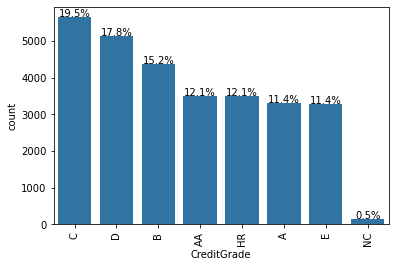

```python
# ploting the variable
base_color = sb.color_palette()[0]
sb.countplot(data=df2, x='CreditGrade', color=base_color,
order=CreditGrade_order);

# get the current tick locations and labels
locs, labels = plt.xticks(rotation=90)

# loop through each pair of locations and labels
for loc, label in zip(locs, labels):
    # get the text property for the label to get the correct count
    count = CreditGrade_counts[label.get_text()]
    pct_string = '{:0.1f}%'.format(100*count/n_CreditGrade)
    # print the annotation just below the top of the bar
    plt.text(loc, count+2, pct_string, ha = 'center', color =
'black')
```

> `The most common credit grade across the profiles in loans dataset is C`

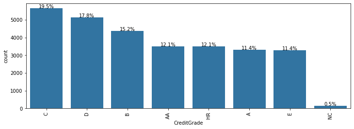

```python
# Adjucting figure size
from matplotlib import rcParams
# Specify the figure size in inches, for both X, and Y axes
rcParams['figure.figsize'] = 12,4

# ploting the variable
base_color = sb.color_palette()[0]
sb.countplot(data=df2, x='CreditGrade', color=base_color,
order=CreditGrade_order);

# get the current tick locations and labels
locs, labels = plt.xticks(rotation=90)

# loop through each pair of locations and labels
for loc, label in zip(locs, labels):
    # get the text property for the label to get the correct count
    count = CreditGrade_counts[label.get_text()]
    pct_string = '{:0.1f}%'.format(100*count/n_CreditGrade)
    # print the annotation just below the top of the bar
    plt.text(loc, count+2, pct_string, ha = 'center', color =
'black')
```

#### Visualize the missing value counts

```python
df2.isna().sum()
```

```
LoanKey                        0
LoanOriginalAmount             0
CreditGrade                84984
Occupation                  3588
Term                           0
LoanStatus                     0
BorrowerRate                   0
LenderYield                    0
EstimatedEffectiveYield    29084
EstimatedLoss              29084
EstimatedReturn            29084
ProsperRating (numeric)    29084
ProsperScore               29084
BorrowerState               5515
EmploymentStatus            2255
IsBorrowerHomeowner            0
AmountDelinquent            7622
LP_CustomerPayments            0
AvailableBankcardCredit     7544
IncomeRange                    0
DebtToIncomeRatio           8554
IncomeVerifiable               0
LP_GrossPrincipalLoss          0
LP_NetPrincipalLoss            0
Investors                      0
LP_ServiceFees                 0
LoanYear                       0
dtype: int64
```

```python
#Let's drop the column that do not have anyN aN/None values
na_counts=df2.drop(['LoanKey','LoanOriginalAmount','Term','LoanYear',
                           'LoanStatus','BorrowerRate','LenderYield','IsBorrowerHomeowner','LP_CustomerPayments','IncomeRange',
                           'LP_GrossPrincipalLoss','LP_NetPrincipalLoss','LP_NetPrincipalLoss','Investors','LP_ServiceFees','IncomeVerifiable'],axis=1).isna().sum()
print(na_counts)
```

```
CreditGrade                84984
Occupation                  3588
EstimatedEffectiveYield    29084
EstimatedLoss              29084
EstimatedReturn            29084
ProsperRating (numeric)    29084
ProsperScore               29084
BorrowerState               5515
EmploymentStatus            2255
AmountDelinquent            7622
AvailableBankcardCredit     7544
DebtToIncomeRatio           8554
dtype: int64
```

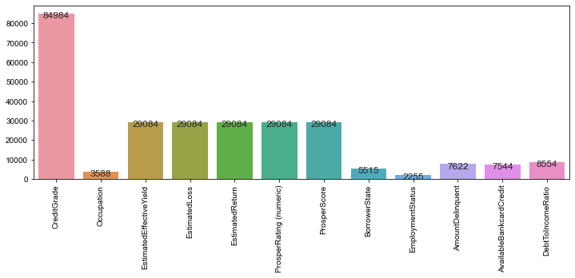

```python
#The first argument to the functionbe low contains the x-values (column names),the second argument they-values(our counts).
sb.barplot(na_counts.index.values,na_counts)
#get the current tick locations and labels
plt.xticks(rotation=90)
sb.set(rc={'figure.figsize':(12,16)})
#Logic to print value on each bar
for i in range(na_counts.shape[0]):
    count = na_counts[i]
    #Refer here for details of the text
    plt.text(i,count+1000,count,ha='center',va='top',size = 'medium')
```

> `This graph indicates the highest variable with the recoed of it's missing values`

#### Exploring the `Term` Variable

```
(-1.1051549867118768,
 1.1046243395023896,
 -1.1052190188111344,
 1.104560307403132)
```

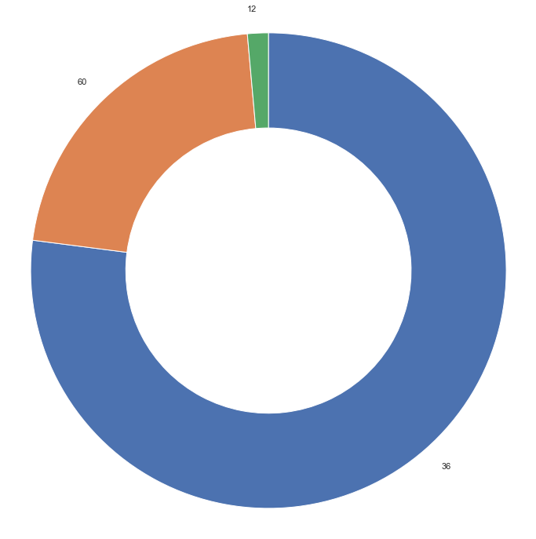

```python
term_s_count = df2['Term'].value_counts()
plt.pie(term_s_count, labels = term_s_count.index, startangle = 90,
 counterclock = False, wedgeprops = {'width' : 0.4});
plt.axis('square')
```

#### We can see that the most frequent term from this graph is `36 Month`

> `Note that those numbers are measured in term of the lenth of loans by Months.`

#### Exploring the `IsBorrowerHomeowner` Variable

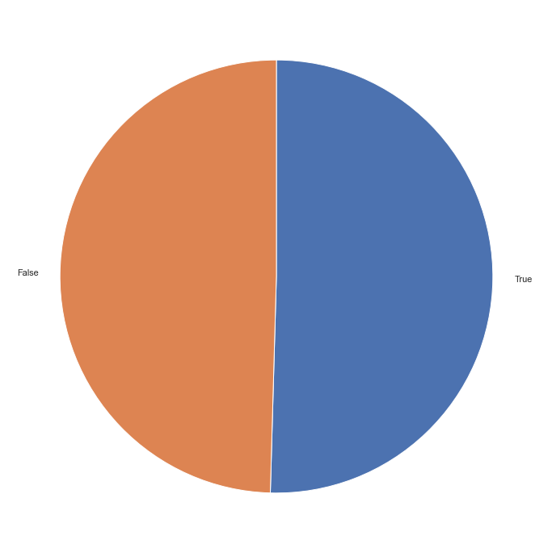

```python
# Use the same loan dataset
IsBorrowerHomeowner_counts = df2['IsBorrowerHomeowner'].value_counts()
plt.pie(IsBorrowerHomeowner_counts, labels = IsBorrowerHomeowner_counts.index, startangle = 90, counterclock =
False);
```

> > `The grap shows that Borrowers that tend to have homes are slightly higher with unnoticed perecentage`

#### Further invistigation on the variable `LoanOriginalAmount` and other relevent variables

```python
df2['LoanOriginalAmount'].nunique()
```

```
2468
```

```python
df2['LoanYear'].value_counts()
```

```
2013    35413
2012    19556
2007    11557
2011    11442
2008    11263
2014    10734
2006     6213
2010     5530
2009     2206
2005       23
Name: LoanYear, dtype: int64
```

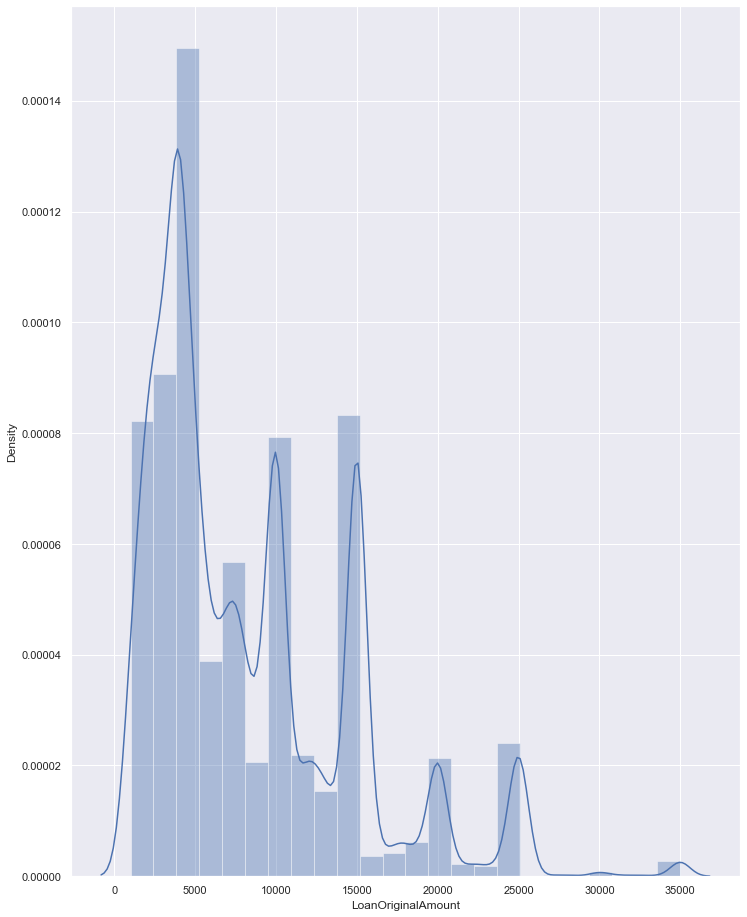

```python
sb.distplot(df2['LoanOriginalAmount'],bins = 24 );
```

> `Here we can see that density are tend to be higher closely to the loan amount of the range of 5000`

```python
# the highest 30 loan across the data
loans_high = df2.nlargest(20, 'LoanOriginalAmount')[['LoanYear','LoanOriginalAmount','LoanStatus', 'Occupation','Term', 'IncomeRange', 'Investors']]
loans_high
```

|  | LoanYear | LoanOriginalAmount | LoanStatus | Occupation | Term | IncomeRange | Investors |
| --- | --- | --- | --- | --- | --- | --- | --- |
| 29 | 2013 | 35000 | Current | Other | 36 | $100,000+ | 1 |
| 637 | 2013 | 35000 | Current | Doctor | 36 | $100,000+ | 88 |
| 687 | 2013 | 35000 | Current | Pilot - Private/Commercial | 60 | $100,000+ | 467 |
| 1223 | 2013 | 35000 | Current | Computer Programmer | 36 | $100,000+ | 1 |
| 1368 | 2013 | 35000 | Current | Executive | 36 | $100,000+ | 1 |
| 1370 | 2013 | 35000 | Current | Sales - Commission | 60 | $100,000+ | 244 |
| 1422 | 2013 | 35000 | Current | Executive | 60 | $100,000+ | 1 |
| 1481 | 2013 | 35000 | Current | Professional | 36 | $100,000+ | 1 |
| 1554 | 2014 | 35000 | Current | Police Officer/Correction Officer | 60 | $100,000+ | 1 |
| 1845 | 2013 | 35000 | Current | Executive | 60 | $100,000+ | 1 |
| 2126 | 2013 | 35000 | Current | Sales - Commission | 36 | $100,000+ | 1 |
| 2288 | 2014 | 35000 | Current | Professional | 36 | $100,000+ | 1 |
| 2539 | 2014 | 35000 | Current | Police Officer/Correction Officer | 60 | $100,000+ | 1 |
| 2636 | 2013 | 35000 | Past Due (1-15 days) | Computer Programmer | 36 | $100,000+ | 1 |
| 3189 | 2013 | 35000 | Current | Executive | 36 | $100,000+ | 654 |
| 3312 | 2014 | 35000 | Current | Nurse (RN) | 36 | $100,000+ | 1 |
| 3598 | 2013 | 35000 | Current | Skilled Labor | 36 | $100,000+ | 1 |
| 3758 | 2013 | 35000 | Current | Doctor | 36 | $100,000+ | 1 |
| 4191 | 2013 | 35000 | Current | Analyst | 60 | $100,000+ | 1 |
| 4566 | 2013 | 35000 | Current | Professional | 60 | $100,000+ | 649 |

> `We can see here that the limit of having a large loan is relative when income of the borrowers is above 100,000, with additional information of the occupation of those people and the term of thier loans is either 36 or 60 Month.`

#### `IncomeRange`,`LoanStatus`,`EmploymentStatus` Variables.

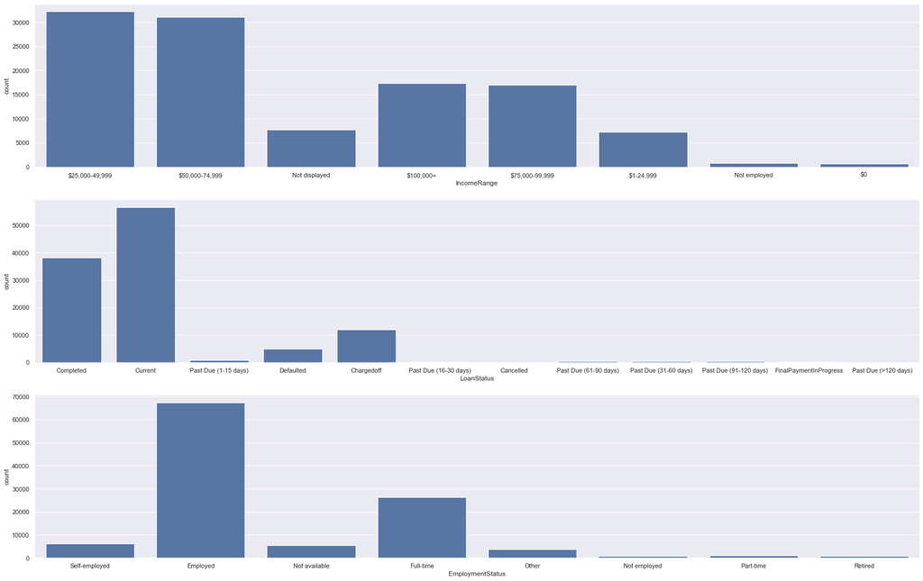

```python
fig, ax = plt.subplots(nrows=3, figsize = [28,18])

default_color = sb.color_palette()[0]
sb.countplot(data = df2, x = 'IncomeRange', color = default_color, ax = ax[0])
sb.countplot(data = df2, x = 'LoanStatus', color = default_color, ax = ax[1])
sb.countplot(data = df2, x = 'EmploymentStatus', color = default_color, ax = ax[2])
plt.show()
```

> `In the (1) and (3) Graph We see that the most borrowers that thier income ranges from 25,000-75,000 have the highest frequency taking loans, and most of those people are employed.`

> `in the (2) Graph there was a high portion of those loans still current(in-progress) and and the rest is completed with close relitive size , defaulted here means they couldn't pay thier debt abd charged off means they charged a higher interest rate because the didnt repay thier loan on time and the remaing amount was scheduled for a another higher interest rate charge`

### Discuss the distribution(s) of your variable(s) of interest. Were there any unusual points? Did you need to perform any transformations?

```
I perfomed a couple of investigation by graphing some of the variable of interest since my major is Finance but i found unusual scale rating for thr creditgrades in terms if definations which is not ecxplanined inside the supported document of terms. it should be fixed as it's in our field the scalling of those grade confused me since i couldn't recognise it.
Also i checked commonly attribute on the data set to be able to start building upon them later.
```

## Bivariate Exploration

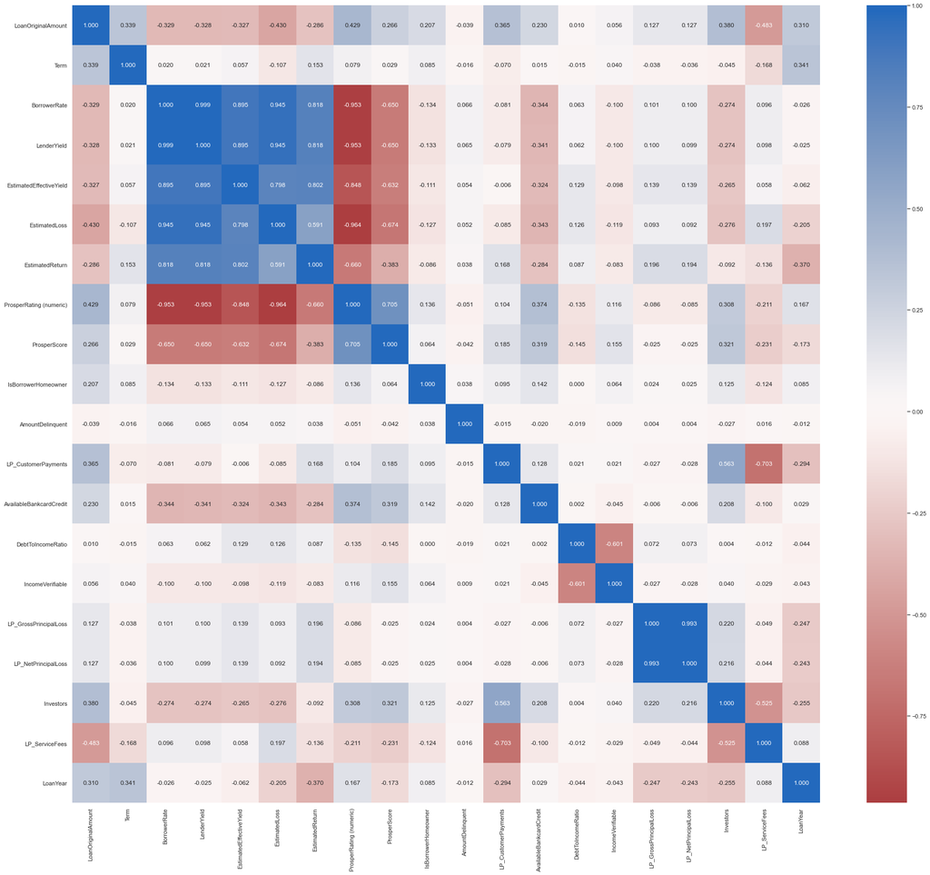

```python
# correlation plot
plt.figure(figsize = [32, 28])
sb.heatmap(df2.corr(), annot = True, fmt = '.3f',
           cmap = 'vlag_r', center = 0)
plt.show()
```

### From this Graph we can try to focus our interest on some interesting relatioships by figuring out the matched correlations between those list of variables.

`BorrowRate Vs YieldRate Vs EstimatedReturn` `DebtToIncomeRatio Vs IncomeVerfiable` `Investors Vs LP_ServiceFees Vs LP_CustomerPayments`

### Years and Amount of loans

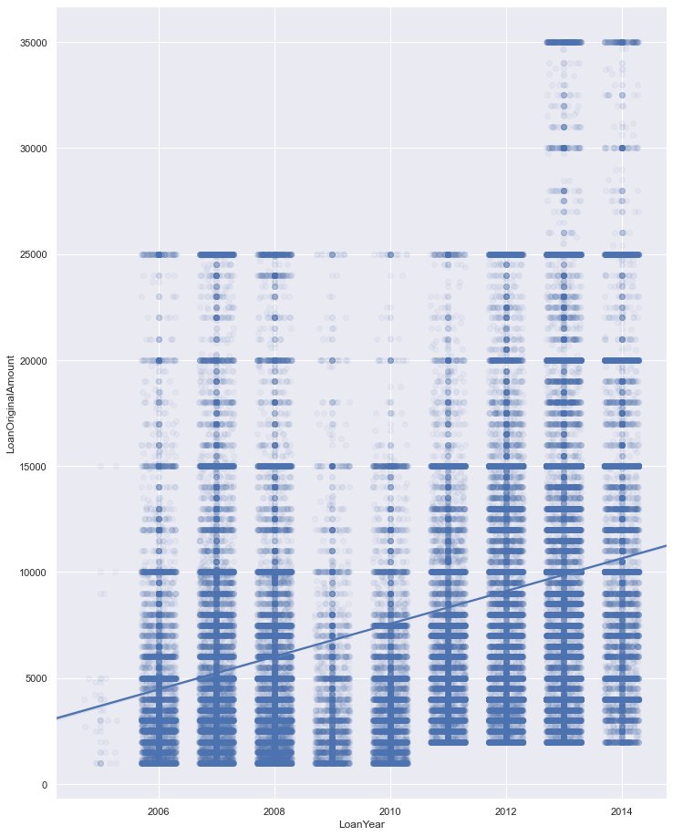

```python
# Scatter plot
# The scatter_kws helps specifying the opaqueness of the data points
# The alpha take a value between [0-1], where 0 represents Transparent,and 1 is opaque.
sb.regplot(data = df2, x = 'LoanYear', y = 'LoanOriginalAmount',
truncate=False, x_jitter=0.3, scatter_kws={'alpha':1/20});
# Alternative way to plot with the transparency.
# The scatter() function below does NOT have any argument to specify the Jitter
plt.scatter(data = df2, x = 'LoanYear', y = 'LoanOriginalAmount', alpha=1/20);
```

### `We Can notice the increase on the amount of loans across timeline`

### Estimated Loss Vs Borrower Rate

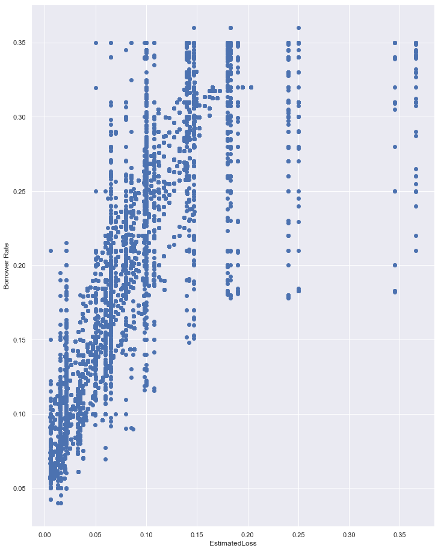

```python
# Scatter plot
plt.scatter(data = df2, x = 'EstimatedLoss', y = 'BorrowerRate');
plt.xlabel('EstimatedLoss')
plt.ylabel('Borrower Rate')
```

> `We can observe that when Borrow Rate increase this effect the Estimated loss for borrowers to increase as thier charge-off propabiltiy increases when a higher interest rate is assigned`|

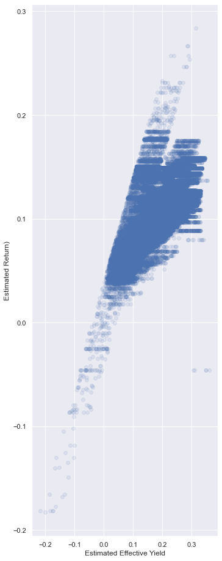

```python
# PLOTING
plt.subplot(1, 2, 1)
sb.regplot(data = df2, x = 'EstimatedEffectiveYield', y = 'EstimatedReturn',
x_jitter=0.04, scatter_kws={'alpha':1/10}, fit_reg=False)
plt.xlabel('Estimated Effective Yield')
plt.ylabel('Estimated Return)');
```

> `As we can see there's a postive correlation b/w those 2 variables as they're linked to drive each other outcome.`

### Years Vs Investors

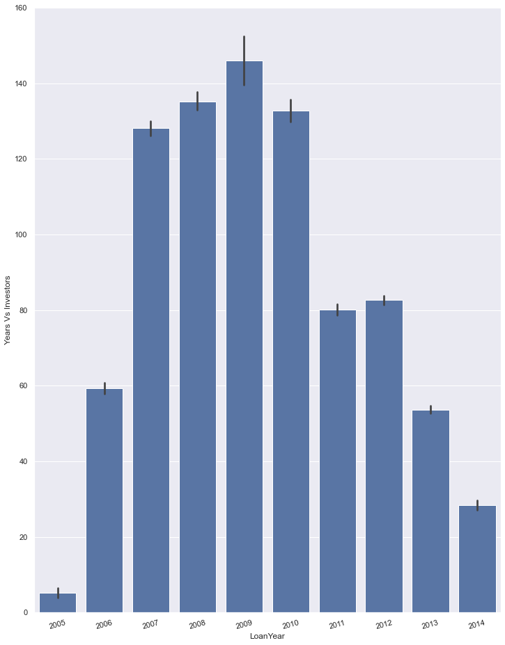

```python
base_color = sb.color_palette()[0]
sb.barplot(data=df2, x='LoanYear', y='Investors', color=base_color)
plt.xticks(rotation=15);
plt.ylabel('Years Vs Investors')
```

> > `From this Graph it shows that the Years with the the highest investment size, as it shows the lowest was represented in 2005`

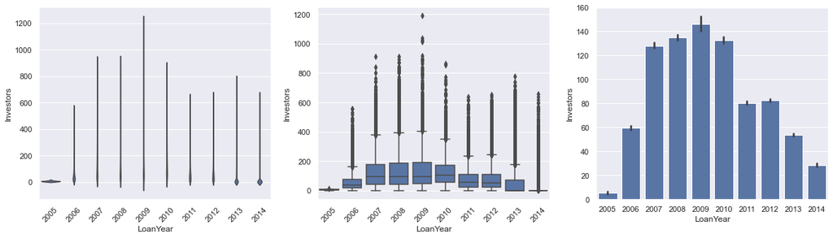

```python
plt.figure(figsize = [20, 5])
base_color = sb.color_palette()[0]
# left plot: violin plot
plt.subplot(1, 3, 1)
sb.violinplot(data=df2, x='LoanYear', y='Investors', inner = None,
 color = base_color)
plt.xticks(rotation = 45); # include label rotation due to small subplot size
# center plot: box plot
plt.subplot(1, 3, 2)
sb.boxplot(data=df2, x='LoanYear', y='Investors', color = base_color)
plt.xticks(rotation = 45);
# right plot: adapted bar chart
plt.subplot(1, 3, 3)
sb.barplot(data=df2, x='LoanYear', y='Investors', color = base_color)
```

> `From this graphs we can identify the amount of outliers in Graph 2, this could be because we're not avaraging the number, so we need to avarge them if we want to resume our analysis on this part`

### Talk about some of the relationships you observed in this part of the investigation. How did the feature(s) of interest vary with other features in the dataset?

There was some Interesting relationships

> `BorrowRate Vs YieldRate Vs EstimatedReturn`

> `DebtToIncomeRatio Vs IncomeVerfiable`

> `Investors Vs LP_ServiceFees Vs LP_CustomerPayments`

### Did you observe any interesting relationships between the other features (not the main feature(s) of interest)?

> `Yeah but there was no Time to explore them. there's alot of variable in this dataset that could give us insights and connect the dots of missing relatioships.`

## LoanYear Vs Occupation / EmploymentStatus / IncomeRange

[figure not shown]

```python
# since there's only three subplots to create, using the full data should be fine.
plt.figure(figsize = [8, 8])

# subplot 1: color vs cut
plt.subplot(3, 1, 1)
sb.countplot(data = df2, x = 'LoanYear', hue = 'Occupation', palette = 'Blues')

# subplot 2: clarity vs. cut
ax = plt.subplot(3, 1, 2)
sb.countplot(data = df2, x = 'LoanYear', hue = 'EmploymentStatus', palette = 'Blues')
ax.legend(ncol = 2) # re-arrange legend to reduce overlapping

# subplot 3: clarity vs. color, use different color palette
ax = plt.subplot(3, 1, 3)
sb.countplot(data = df2, x = 'LoanYear', hue = 'IncomeRange', palette = 'Greens')
ax.legend(loc = 1, ncol = 2)
# re-arrange legend to remove overlapping

plt.show()
```

> `From the following Graphs we can can the the timeline and the changes in some of the relative variable of interest and thier freqency acroos years`

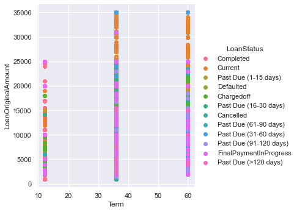

```python
g = sb.FacetGrid(data = df, hue = 'LoanStatus', size = 5)
g.map(plt.scatter, 'Term', 'LoanOriginalAmount')
g.add_legend()
```

## BorrowerRate Vs EmploymentStatus Vs IncomeRange

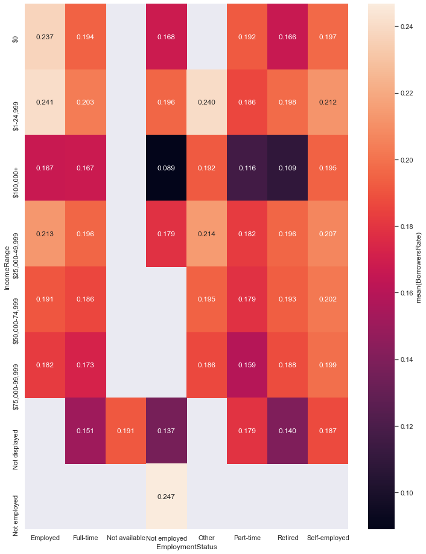

```python
Bor_rate = df2.groupby(['EmploymentStatus', 'IncomeRange']).mean()['BorrowerRate']
Bor_rate = Bor_rate.reset_index(name = 'BorrowersRate')
Bor_rate = Bor_rate.pivot(index = 'IncomeRange', columns = 'EmploymentStatus',
 values = 'BorrowersRate')
sb.heatmap(Bor_rate, annot = True, fmt = '.3f',
 cbar_kws = {'label' : 'mean(BorrowersRate)'})
```

## Loan Original Amount Vs Is Borrower Homeowner Vs Available Bank Card Credit

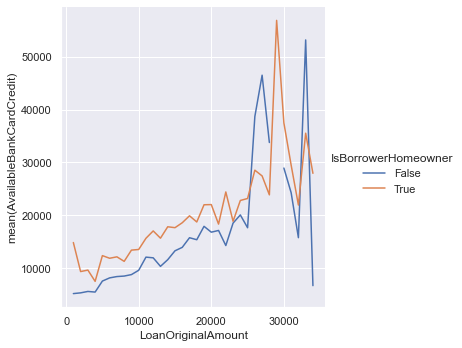

```python
def mean_poly(x, y, bins = 10, **kwargs):
    # set bin edges if none or int specified
    if type(bins) == int:
        bins = np.linspace(x.min(), x.max(), bins+1)
    bin_centers = (bin_edges[1:] + bin_edges[:-1]) / 2
    # compute counts
    data_bins = pd.cut(x, bins, right = False,include_lowest = True)
    means = y.groupby(data_bins).mean()
    # create plot
    plt.errorbar(x = bin_centers, y = means, **kwargs)

bin_edges = np.arange(500, df2['LoanOriginalAmount'].max()+500, 1000)
g = sb.FacetGrid(data = df2, hue = 'IsBorrowerHomeowner', size = 5)
g.map(mean_poly, "LoanOriginalAmount", "AvailableBankcardCredit", bins = bin_edges)
g.set_ylabels('mean(AvailableBankCardCredit)')
g.add_legend()
```

> `the graphs shows indicate the relatioship betwween various variables that could effect the Credability if the borrowers`

### Talk about some of the relationships you observed in this part of the investigation. Were there features that strengthened each other in terms of looking at your feature(s) of interest?

> ```
> We had some interesing and relvent relatioships  on the association of having higher credit grade but there was a problem i faced not understanding the grading system since it's not familiar to me despite that having a finance background and even checked it but i couldn't finf it well.
> some if those terms like " the probaibilty of having a home owned by the borrower or having a stable source of income to give the borowser the credibilty if taking larger amount of loans and fullfill it without causing the interest rate to icrease becuse of crossing the due date.
> other interesting variables as well the employment status and profession of the borowser.
> ```